# Project Python Foundations: FoodHub Data Analysis

#### Orders concentration

This section will focus on orders concentration since the goal of the analysis is to understand the demand to enhance customer experience.

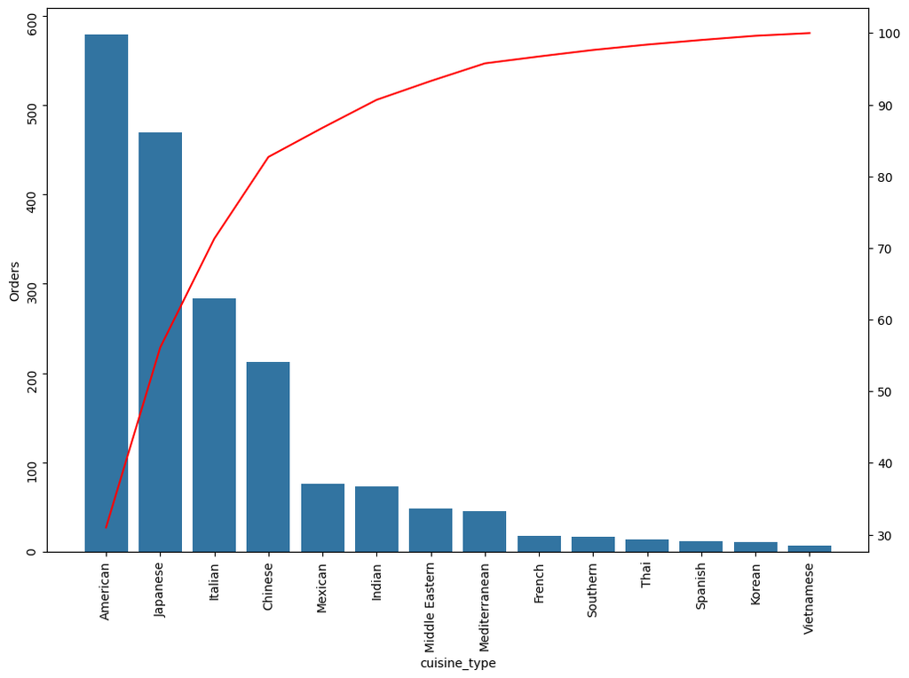

```python
df_plot = df_treated.sort_values('cuisine_type').groupby(['cuisine_type']).agg({'order_id':'count'}).sort_values(by='order_id',ascending=False)
df_plot.rename(columns={'order_id': 'Orders'}, inplace=True)
df_plot['Cumulative Sum'] = df_plot.cumsum()
total_orders = df_plot['Orders'].sum()
df_plot['Cumulative Percentage'] = (df_plot['Cumulative Sum'] / total_orders) * 100

fig, ax1 = plt.subplots(figsize=(12, 8))

sns.barplot(x=df_plot.index, y=df_plot['Orders'], ax=ax1)
ax1.tick_params(rotation=90)
ax2 = ax1.twinx()
ax2.plot(ax1.get_xticks(), df_plot['Cumulative Percentage'], color='red')
plt.show()
```

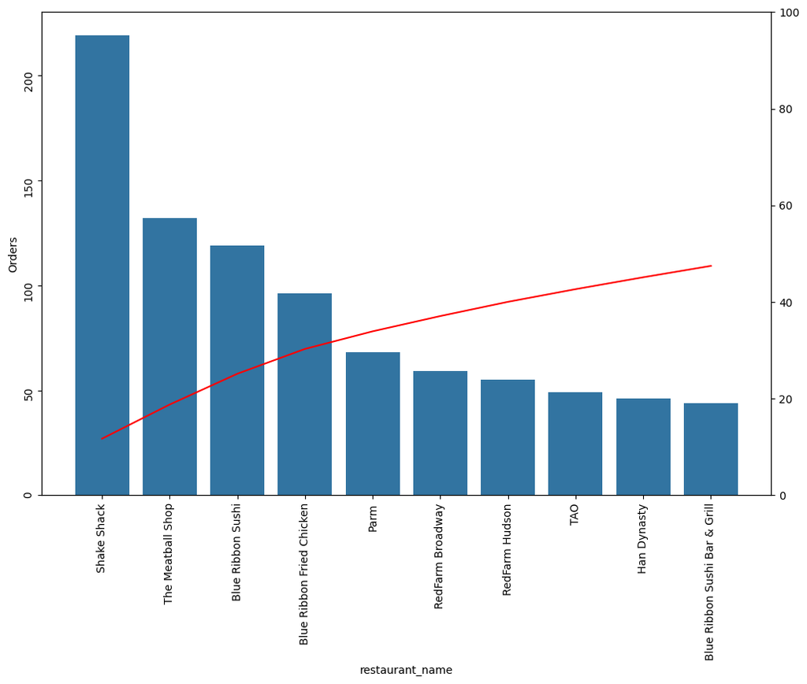

```python
df_plot = df_treated.sort_values('restaurant_name').groupby(['restaurant_name']).agg({'order_id':'count'}).sort_values(by='order_id',ascending=False)
df_plot.rename(columns={'order_id': 'Orders'}, inplace=True)
df_plot['Cumulative Sum'] = df_plot.cumsum()
total_orders = df_plot['Orders'].sum()
df_plot['Cumulative Percentage'] = (df_plot['Cumulative Sum'] / total_orders) * 100
df_plot = df_plot.sort_values(by='Orders',ascending=False).head(10)

fig, ax1 = plt.subplots(figsize=(12, 8))

sns.barplot(x=df_plot.index, y=df_plot['Orders'], ax=ax1)
ax1.tick_params(rotation=90)
ax2 = ax1.twinx()
ax2.plot(ax1.get_xticks(), df_plot['Cumulative Percentage'], color='red')
ax2.set_ylim(0, 100)
plt.show()
```

- Approximately, 50% of orders is concentrated in the top 10 restaurants

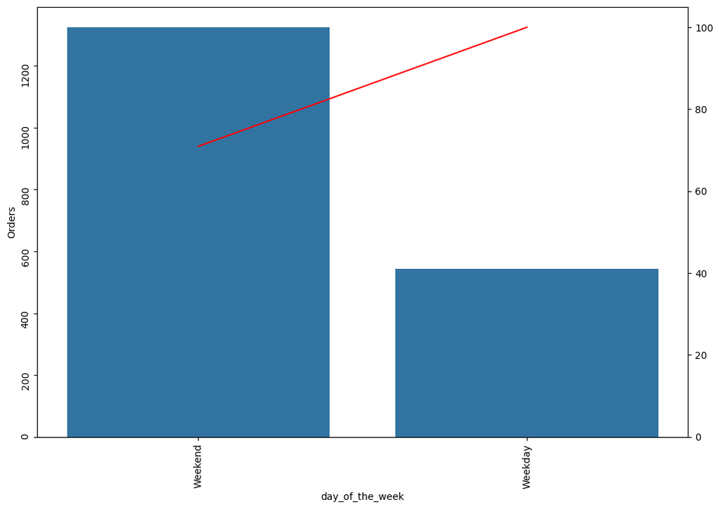

```python
df_plot = df_treated.sort_values('day_of_the_week').groupby(['day_of_the_week']).agg({'order_id':'count'}).sort_values(by='order_id',ascending=False)
df_plot.rename(columns={'order_id': 'Orders'}, inplace=True)
df_plot['Cumulative Sum'] = df_plot.cumsum()
total_orders = df_plot['Orders'].sum()
df_plot['Cumulative Percentage'] = (df_plot['Cumulative Sum'] / total_orders) * 100
df_plot = df_plot.sort_values(by='Orders',ascending=False).head(10)

fig, ax1 = plt.subplots(figsize=(12, 8))

sns.barplot(x=df_plot.index, y=df_plot['Orders'], ax=ax1)
ax1.tick_params(rotation=90)
ax2 = ax1.twinx()
ax2.plot(ax1.get_xticks(), df_plot['Cumulative Percentage'], color='red')
ax2.set_ylim(0, 105)
plt.show()
```

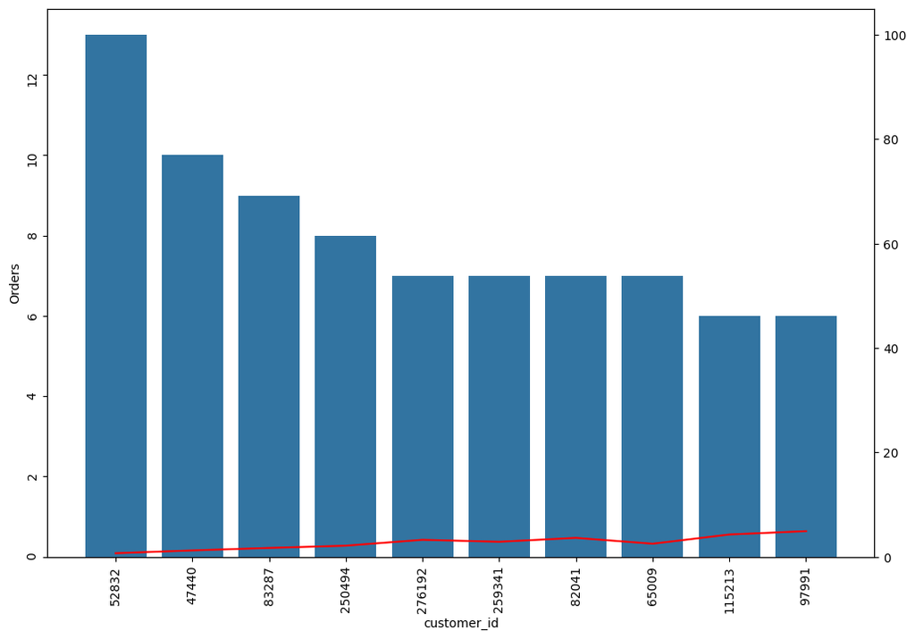

```python
df_plot = df_treated.sort_values('customer_id').groupby(['customer_id']).agg({'order_id':'count'}).sort_values(by='order_id',ascending=False)
df_plot.rename(columns={'order_id': 'Orders'}, inplace=True)
df_plot['Cumulative Sum'] = df_plot.cumsum()
total_orders = df_plot['Orders'].sum()
df_plot['Cumulative Percentage'] = (df_plot['Cumulative Sum'] / total_orders) * 100
df_plot = df_plot.sort_values(by='Orders',ascending=False).head(10)

fig, ax1 = plt.subplots(figsize=(12, 8))

sns.barplot(x=df_plot.index, y=df_plot['Orders'], ax=ax1)
ax1.tick_params(rotation=90)
ax2 = ax1.twinx()
ax2.plot(ax1.get_xticks(), df_plot['Cumulative Percentage'], color='red')
ax2.set_ylim(0, 105)
plt.show()
```

- There is not a large concentration of orders in customers, which it is not bad per se, because we want to get to as many customers as possible. However, it is possible to plan strategies to enhance customer loyalty.

Final observations: In the univariate analysis, it was possible to observe order concentration in three features: cuisine type, restaurant name and day of the week. The graphs above support the hypothesis of order concentration, because with them, we can conclude that the demand is concentrated in few cuisine types, restaurants and weekends. Let's get a deeper understanding of the relationship between those three features and others in bivariante and multivariate analysis.

#### Relationship between day of the week and other features

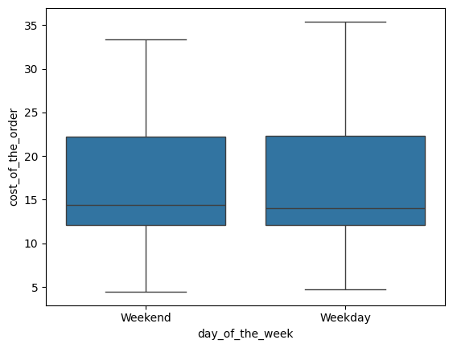

```python
# Plots boxplots between day of the week (x axis) and cost of the order (y axis)
sns.boxplot(data=df_treated,x='day_of_the_week',y='cost_of_the_order')
plt.show()
```

- There seems to be no relationship between day of the week and cost of the order

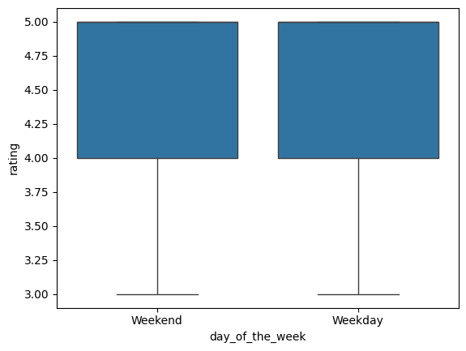

```python
# Plots boxplots between day of the week (x axis) and rating (y axis)
sns.boxplot(data=df_treated,x='day_of_the_week',y='rating')
plt.show()
```

- There seems to be no relationship between day of the week and rating

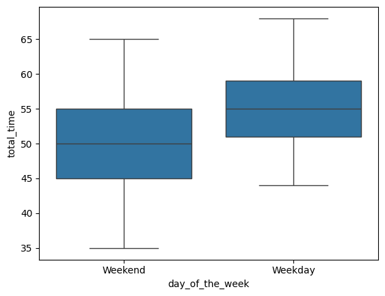

```python
# Plots boxplots between day of the week (x axis) and total_time (y axis)
sns.boxplot(data=df_treated,x='day_of_the_week',y='total_time')
plt.show()
```

- The total time of delivery of an order tends to be higher in weekdays

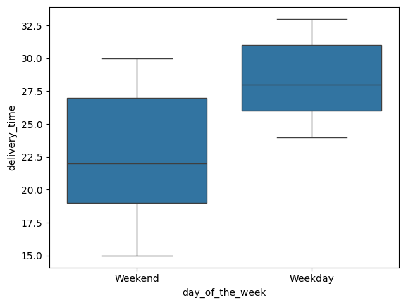

```python
# Plots boxplots between day of the week (x axis) and  delivery time (y axis)
sns.boxplot(data=df_treated,x='day_of_the_week',y='delivery_time')
plt.show()
```

- The delivery time of an order tends to be higher in weekdays

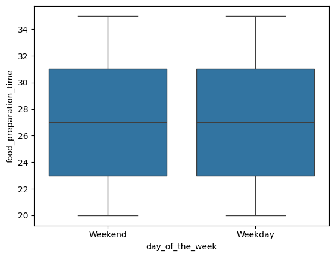

```python
# Plots boxplots between day of the week (x axis) and  food preparation time (y axis)
sns.boxplot(data=df_treated,x='day_of_the_week',y='food_preparation_time')
plt.show()
```

- There seems to be no relationship between day of the week and food preparation time

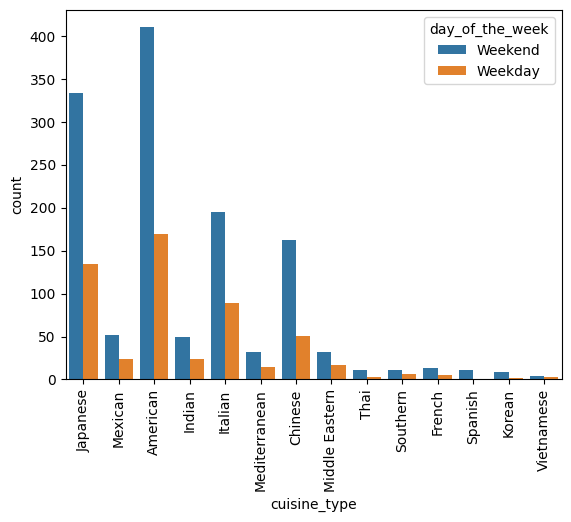

```python
# Plots a countplot of cuisine type (x axis) divided by day of the week

sns.countplot(data=df_treated, x='cuisine_type', hue='day_of_the_week')
plt.xticks(rotation=90)
plt.show()
```

- The demand of orders during weekends is higher for all the cuisine types

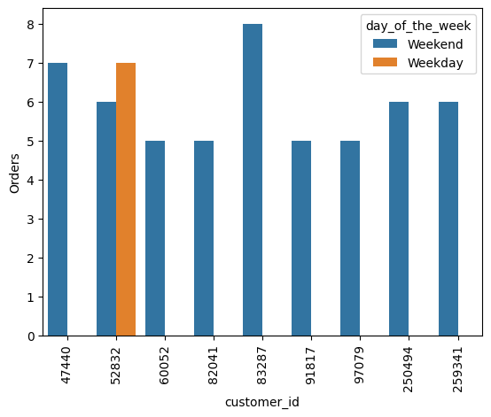

```python
# Groups the dataset by customer_id and day of the week and aggregate counting the number of orders for each category
df_customers = df_treated.sort_values('customer_id').groupby(['customer_id', 'day_of_the_week']).agg({'order_id':'count'}).nlargest(10, 'order_id').reset_index().sort_values('order_id', ascending=False)
df_customers.rename(columns={'order_id': 'Orders'}, inplace=True)

# Plots a bar plot of the most frequent customers (x axis) and orders (y axis) divided by day of the week
sns.barplot(data=df_customers, x='customer_id', y='Orders', hue='day_of_the_week')
plt.xticks(rotation=90)
plt.show()
```

- Only one of the most frequent customers placed orders on weekdays

Final observations:

- There seems to be no relationship between day of the week and cost of the order, rating or food preparation time.
- Delivery time is significantly higher on weekdays, which can be a problem for people trying to eat fast in commercial hours. Drivers availability on weekdays should be guaranteed.
- Also, it is possible to note that only one of the most frequent customers has placed orders during the week. So, the concentration of orders in weekends is true even for the most frequent customers.
- Overall, it is necessary to work on getting more orders and ensuring drivers availability during weekdays.

#### Relationship between cuisine type and other features

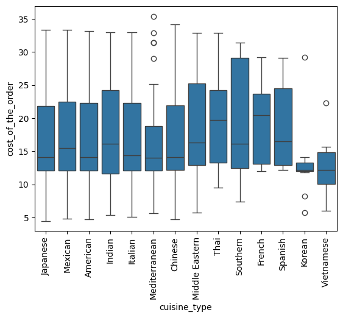

```python
# Plots boxplots between cuisine type (x axis) and cost of the order (y axis)
sns.boxplot(data=df_treated,x='cuisine_type',y='cost_of_the_order')
plt.xticks(rotation=90)
plt.show()
```

- Most cuisine types have 50% of the orders under 20 dollars, except for Frech cuisine.
- There are some outliers in the distributions of Mediterranean, Korean and Vietnamese cuisines

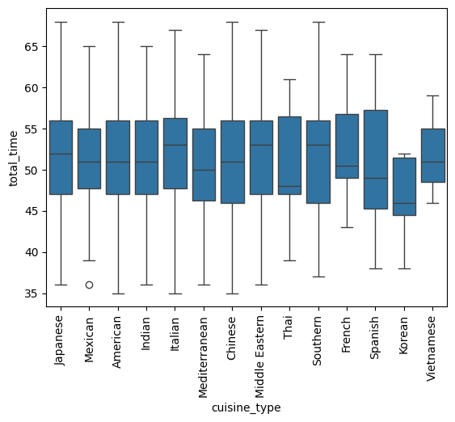

```python
# Plots boxplots between cuisine type (x axis) and total time (y axis)
sns.boxplot(data=df_treated,x='cuisine_type',y='total_time')
plt.xticks(rotation=90)
plt.show()
```

- All cuisine types have at least 75% of the orders under 60 minutes of total delivery time.

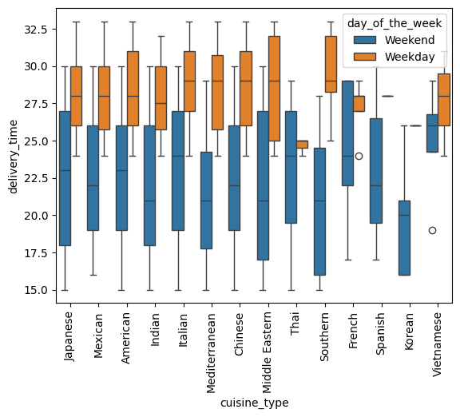

```python
# Plots boxplots between cuisine type (x axis) and delivery time (y axis) divided by day of the week
sns.boxplot(data=df_treated,x='cuisine_type',y='delivery_time', hue='day_of_the_week')
plt.xticks(rotation=90)
plt.show()
```

- Delivery time tends to be higher on week days for every cuisine type

Final observations:

- Again, it is possible to conclude that the delivery time seems to be higher on week days, even when we look through different types of cuisine.

#### Relationship between most frequent restaurants and other features

```python
# Creates a list of the top 10 most frequent customers
most_frequent_restaurants = df_treated.sort_values('restaurant_name').groupby(['restaurant_name']).agg({'order_id':'count'}).sort_values(by='order_id',ascending=False).nlargest(10, columns='order_id').reset_index()['restaurant_name'].to_list()
# Creates a boolean with indicantes if those frequent customers are present in rows
df_most_frequent_restaurants = df_treated['restaurant_name'].isin(most_frequent_restaurants)
# Filters only the rows with most frequent customers
df_most_frequent_rests = df_treated[df_most_frequent_restaurants]
```

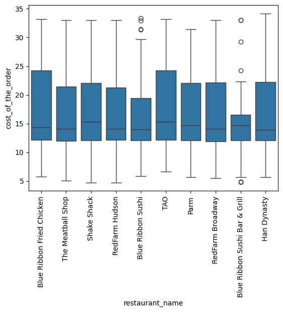

```python
# Plots boxplots between restaurant name (x axis) and cost of the order (y axis)
sns.boxplot(data=df_most_frequent_rests,x='restaurant_name',y='cost_of_the_order')
plt.xticks(rotation=90)
plt.show()
```

- All orders are under 35 dollars in the most frequent restaurants.
- There are a few outliers in cost of the order for Blue Ribbon Sushi and Blue Ribbon Sushi Bar & Grill, but it does not change the overall distribution.

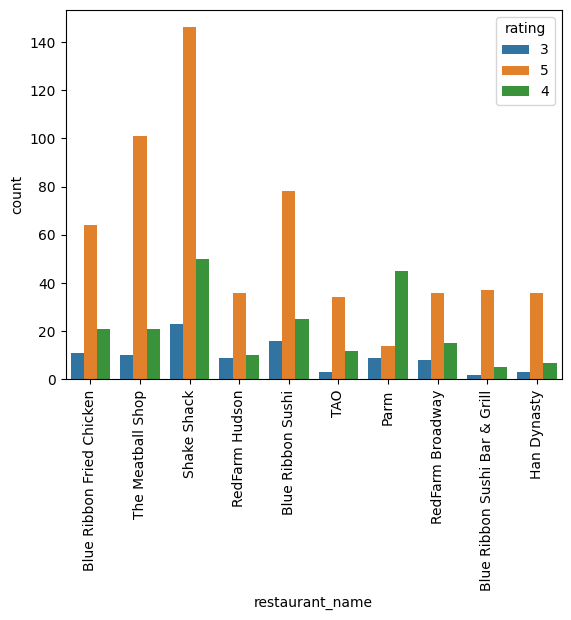

```python
# Plots a countplot of restaurant name (x axis) divided by rating
sns.countplot(data=df_most_frequent_rests,x='restaurant_name',hue='rating')
plt.xticks(rotation=90)
plt.show()
```

- Every top restaurant concentrates its ratings on 4 and 5

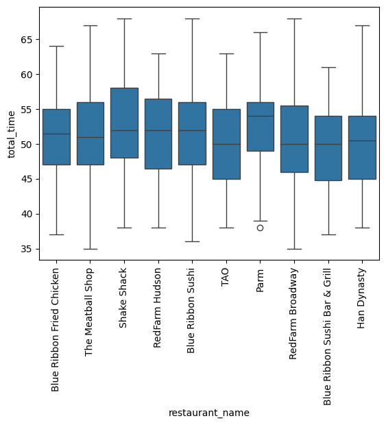

```python
sns.boxplot(data=df_most_frequent_rests,x='restaurant_name',y='total_time')
plt.xticks(rotation=90)
plt.show()
```

- At least 75% of the orders are under 60 minutes for each one of these restaurants

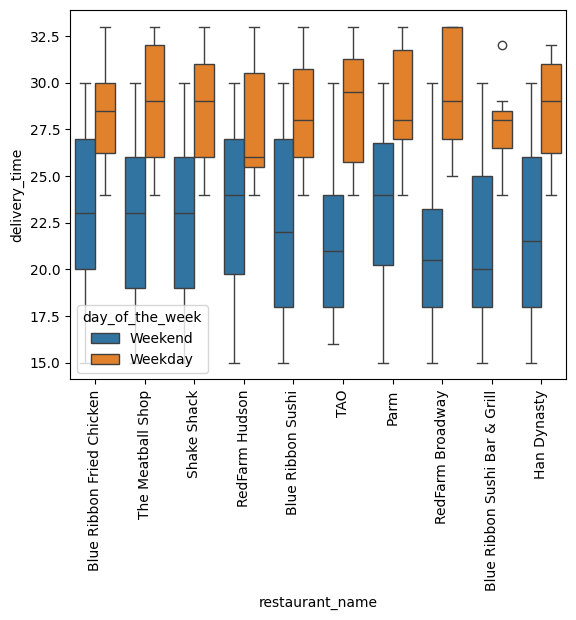

```python
sns.boxplot(data=df_most_frequent_rests,x='restaurant_name',y='delivery_time', hue='day_of_the_week')
plt.xticks(rotation=90)
plt.show()
```

- Even for the top restaurants, there is higher delivery time on weekdays

Final observations

There is some patterns in all top restaurants:

- The costs of the orders are under 35 dollars
- Total time of delivery tends to be under 60 minutes
- There is demand on weekdays, even though the demand on weekends are higher
- The delivery time of orders in those restaurants is still higher on weekdays

### **Question 13:** The company wants to provide a promotional offer in the advertisement of the restaurants. The condition to get the offer is that the restaurants must have a rating count of more than 50 and the average rating should be greater than 4. Find the restaurants fulfilling the criteria to get the promotional offer. [3 marks]

```python
# Excludes rows with not given ratings from the dataset
df_rating_num = df[df['rating'] != 'Not given'].copy()
# Transforms rating into a float data type
df_rating_num['rating'] = df_rating_num['rating'].astype('float')

# Creates a list of unique values on restaurants which have more than 50 ratings and the average rating is freater than 4
df_rating_num.groupby('restaurant_name').filter(lambda x: x['rating'].count() > 50 and x['rating'].mean() > 4)['restaurant_name'].unique()
```

```
array(['Blue Ribbon Fried Chicken', 'Shake Shack', 'Blue Ribbon Sushi',
       'The Meatball Shop'], dtype=object)
```

#### Observations:

The restaurants fulfilling the criteria are: Blue Ribbon Fried Chicken, Shake Shack, Blue Ribbon Sushi, The Meatball Shop

### **Question 14:** The company charges the restaurant 25% on the orders having cost greater than 20 dollars and 15% on the orders having cost greater than 5 dollars. Find the net revenue generated by the company across all orders. [3 marks]

```python
# Creates a net revenue column using conditional functions to calculate the net revenue
df_treated['net_revenue'] = np.where(df_treated['cost_of_the_order'] > 20, df_treated['cost_of_the_order'] * 0.25, 0) + np.where((df_treated['cost_of_the_order'] > 5) & (df_treated['cost_of_the_order'] <= 20), df_treated['cost_of_the_order'] * 0.15, 0)
df_treated['net_revenue'].sum()
```

```
np.float64(6069.882)
```

#### Observations:

The net revenue generated is 6069.88 dollars.

### **Question 15:** The company wants to analyze the total time required to deliver the food. What percentage of orders take more than 60 minutes to get delivered from the time the order is placed? (The food has to be prepared and then delivered.) [2 marks]

```python
# Divides the number of orders with total delivery time higher than 60 by the total number of entries in the dataset
df_treated[df_treated['total_time'] > 60]['total_time'].count()/df_treated['total_time'].count()
```

```
np.float64(0.10546038543897217)
```

#### Observations:

10% of orders take more than 60 minutes to be delivered.

### **Question 16:** The company wants to analyze the delivery time of the orders on weekdays and weekends. How does the mean delivery time vary during weekdays and weekends? [2 marks]

```python
# Groups the dataset by day of the week and gets the mean of the delivery time column
df_treated.groupby('day_of_the_week')['delivery_time'].mean()
```

| day_of_the_week | delivery_time |
| --- | --- |
| Weekday | 28.329650 |
| Weekend | 22.486792 |

**dtype:** float64

#### Observations:

The mean delivery time in weekdays is 28 minutes and 22 minutes in the weekend, so it varies in six minutes.

### Conclusion and Recommendations

### **Question 17:** What are your conclusions from the analysis? What recommendations would you like to share to help improve the business? (You can use cuisine type and feedback ratings to drive your business recommendations.) [6 marks]

### Conclusions:

There is no concentration of orders in customers, which can be a good thing, since we are trying to reach the maximum number of customers as possible. On the other hand, the absolute number of orders per customers is still low (the highest number of orders by customer is 13).

Contrary to intuition, there are no relationship between general rating and other features of the dataset. However, when we deep dive on cuisine types, we see that:

1. In Mexican cuisine, there is a medium negative linear correlation between total time of delivery and ratings, as well as a weak non linear correlation between cost of the order and rating.
2. Contrary to intuition, in Indian Cuisine, there is weak positive correlation between rating and cost of the order (non linear) and rating and total time of delivery (linear).

Although we are not talking about strong correlations, it is important to note that, given the goal of the analysis and the fact that Indian and Mexican Cuisines seem to be potential markets for growth. Thete tips can help to raise demand and get better customer experience on there cuisine types.

```python
 !jupyter nbconvert --to html PYF_VICTORIA_ERMANTRAUT_GANDOLFI\(2\).ipynb
```

```
[NbConvertApp] Converting notebook PYF_VICTORIA_ERMANTRAUT_GANDOLFI(2).ipynb to html
[NbConvertApp] WARNING | Alternative text is missing on 50 image(s).
[NbConvertApp] Writing 2595745 bytes to PYF_VICTORIA_ERMANTRAUT_GANDOLFI(2).html
```